# Final Report: Social Segregation Across the US

Joshua Mark

July 23, 2026

```r
# Select cities
detroit <- data |> filter(METRO_NAME == "Detroit-Warren-Dearborn, MI")

tampa <- data |> filter(METRO_NAME == "Tampa-St. Petersburg-Clearwate")
```

# 1 Introduction

Although de jure segregation has been banned in the United States for over half a century, patterns continue to persist. Nationwide, historical processes alongside contemporary factors continue to draw lines across cities. The goal of this report is to use regression analysis to understand patterns of social segregation in historically redlined cities.

For this analysis, case studies of Detroit, a legacy industrial city, and Tampa, a fast-growing sunbelt city, will be compared and contrasted in order to understand how differing contexts shapes segregation patterns. To measure segregation, a metric known as the Index of Concentration at the Extremes (ICE) will be used.

# 2 Exploratory Spatial Analysis

First, this report will provide an exploratory analysis of each city, including descriptive statistics, a map of index concentration extremes, and a clustering analysis.

## 2.1 Detroit

### 2.1.1 Descriptive Stats

```r
## table of descriptive stats of median income
detroit |> st_drop_geometry() |>
  select(index_concentration_extremes) |>
  summarise(
    n = n(),
    mean_ice = mean(index_concentration_extremes, na.rm = TRUE),
    median_ice = median(index_concentration_extremes, na.rm = TRUE),
    sd_ice = sd(index_concentration_extremes, na.rm = TRUE),
    mean_dev = mean(abs(index_concentration_extremes - mean(index_concentration_extremes, na.rm = TRUE)), na.rm = TRUE),
    min_ice = min(index_concentration_extremes, na.rm = TRUE),
    max_ice = max(index_concentration_extremes, na.rm = TRUE),
    skewness = skewness(index_concentration_extremes, na.rm = TRUE),
    kurtosis = kurtosis(index_concentration_extremes, na.rm = TRUE)

  ) |> pivot_longer(everything(), names_to = "Statistic", values_to = "Value") |>
  gt() |>
  tab_header(
    title = "Index Concentration Extremes, Detroit",
  ) %>%
  fmt_number(
    columns = everything(),
    decimals = 2
  )
```

Index Concentration Extremes, Detroit

| Statistic | Value |
| --- | --- |
| n | 443.00 |
| mean_ice | −0.06 |
| median_ice | −0.12 |
| sd_ice | 0.33 |
| mean_dev | 0.28 |
| min_ice | −0.78 |
| max_ice | 0.78 |
| skewness | 0.41 |
| kurtosis | −0.71 |

The descriptive statistics indicate a city skewing towards disadvantaged, with ICE central tendency in the negatives. An interesting note here is the skew: the median is -0.12, while the mean is -0.06. This indicates a positive tail skewing the average up, likely the result of isolated, affluent communities separate from most of the city. The range is large, going from -0.78 to 0.78, which could be more indication of high segregation or inequality.

In 2013, the City of Detroit entered bankruptcy. This was driven by a number of factors, including population decline, the decline of industrial and manufacturing jobs, and overall, the loss of a sustainable tax base. Though there have been improvements, the city still struggles to support itself. This could explain the mean ICE being as negative as it is, indicating widespread underprivileged areas. Scholars argue the city’s extensive history of racial conflict and segregation was likely at least a catalyst for many of the city’s economic issues (Farley, 2015).

### 2.1.2 Map

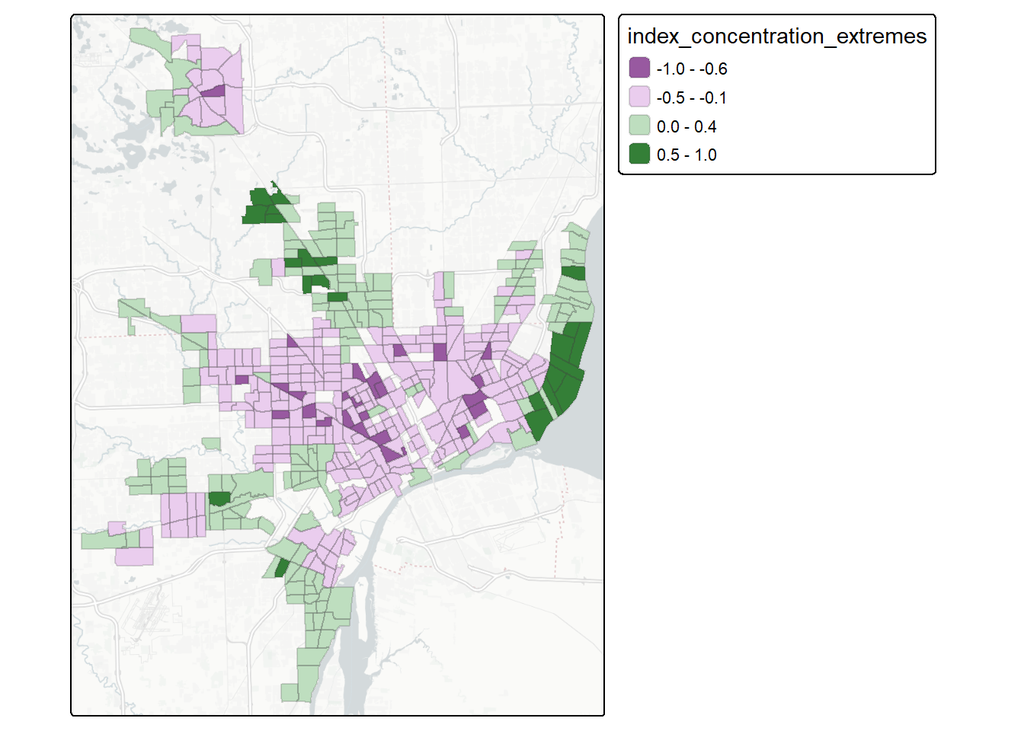

```r
tm_shape(detroit) +
  tm_polygons("index_concentration_extremes", col_alpha = 0.2) +
  tm_basemap("CartoDB.PositronNoLabels")
```

The map confirms the speculation from the descriptive statistics. Most of the ICE values are in the negative, with particularly strong concentration in the center of the city, while a strong concentration of high-privilege communities exist along the east side, near the coast. As a legacy industrial city, this divide can be interpreted along the lines of core, inner-city areas, historically the industrial center, as opposed to newer, suburban areas on the periphery.

This pattern falls in line with maps related to white flight within the city, a famous aspect of Detroit’s history. Between 1950 to 1980, many historically white communities within the center of the city moved en masse, a response to an influx of predominantly Black Americans attracted to industrial work in the center of the city following World War 2 in a period known as the Second Great Migration (Gorrepati, 2024).

### 2.1.3 Cluster Analysis

**Global Structure**

```r
#calculate neighborhoods (queens)
nb_detroit <- poly2nb(detroit, queen = TRUE)

#set neighborhood weight matrix
nbw_detroit <- nb2listw(nb_detroit, style = "W", zero.policy = T)

#calculate Morans I
gmoran_detroit <- moran.mc(detroit$index_concentration_extremes, nbw_detroit, nsim = 99)
gmoran_detroit
```

```
##
##  Monte-Carlo simulation of Moran I
##
## data:  detroit$index_concentration_extremes
## weights: nbw_detroit
## number of simulations + 1: 100
##
## statistic = 0.74226, observed rank = 100, p-value = 0.01
## alternative hypothesis: greater
```

The result indicates very high clustering with a Moran’s I of 0.74 and a significant p-value. This means areas of high privilege and low privilege are spatially, which is evidence of segregation.

**Local Structure**

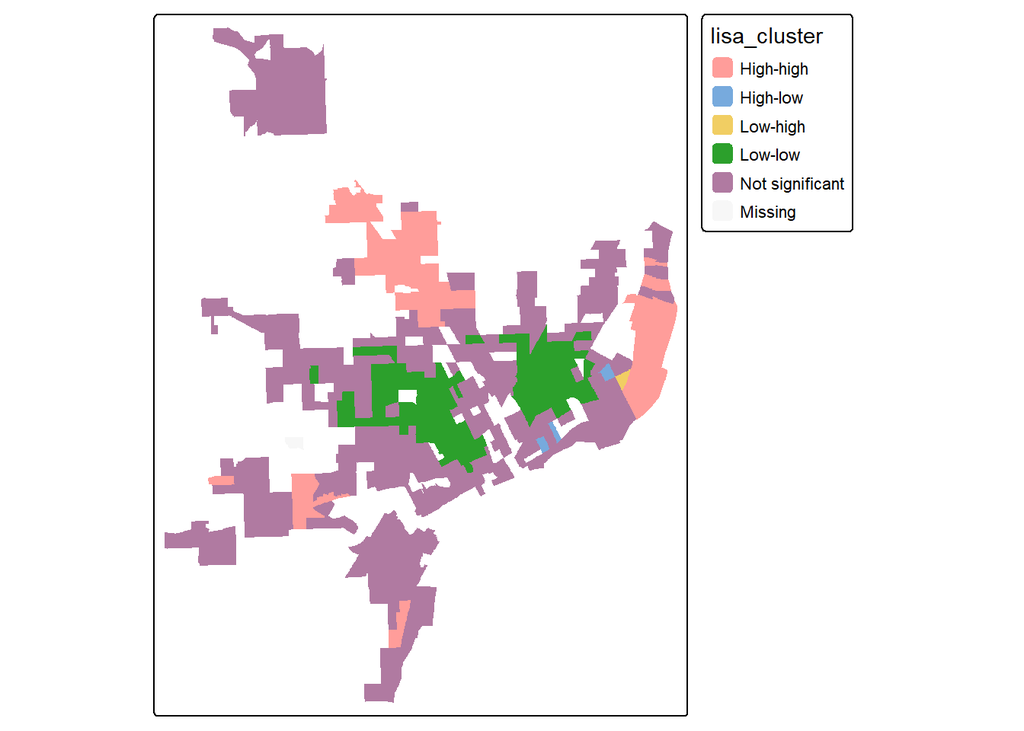

```r
locali_detroit <-localmoran_perm(detroit$index_concentration_extremes, nbw_detroit) %>%
  as_tibble() %>%
  set_names(c("local_i", "exp_i", "var_i", "z_i", "p_i",
              "p_i_sim", "pi_sim_folded", "skewness", "kurtosis"))

#bind LISA results
detroit_LISA <- detroit %>%
  bind_cols(locali_detroit)

#Divide into quadrants
detroit_LISA <- detroit_LISA %>%
  mutate(incz =  as.numeric(scale(index_concentration_extremes)),
         evratezlag = lag.listw(nbw_detroit, incz),
         lisa_cluster = case_when(
           p_i >= 0.05 ~ "Not significant",
           incz > 0 & local_i > 0 ~ "High-high",
           incz > 0 & local_i < 0 ~ "High-low",
           incz < 0 & local_i > 0 ~ "Low-low",
           incz < 0 & local_i < 0 ~ "Low-high"
         ))

#Map
tm_shape(detroit_LISA) + tm_polygons("lisa_cluster", col_alpha = 0)
```

The LISA analysis confirms the regions identified on the map. Low-low concentrations appear in the middle, with high-high concentrations on eastern coast as identified earlier, along with the north, again outside the city center.

## 2.2 Tampa

### 2.2.1 Descriptive Stats

```r
## table of descriptive stats of median income
tampa |> st_drop_geometry() |>
  select(index_concentration_extremes) |>
  summarise(
    n = n(),
    mean_ice = mean(index_concentration_extremes, na.rm = TRUE),
    median_ice = median(index_concentration_extremes, na.rm = TRUE),
    sd_ice = sd(index_concentration_extremes, na.rm = TRUE),
    mean_dev = mean(abs(index_concentration_extremes - mean(index_concentration_extremes, na.rm = TRUE)), na.rm = TRUE),
    min_ice = min(index_concentration_extremes, na.rm = TRUE),
    max_ice = max(index_concentration_extremes, na.rm = TRUE),
    skewness = skewness(index_concentration_extremes, na.rm = TRUE),
    kurtosis = kurtosis(index_concentration_extremes, na.rm = TRUE)

  ) |> pivot_longer(everything(), names_to = "Statistic", values_to = "Value") |>
  gt() |>
  tab_header(
    title = "Index Concentration Extremes, Tampa",
  ) %>%
  fmt_number(
    columns = everything(),
    decimals = 2
  )
```

Index Concentration Extremes, Tampa

| Statistic | Value |
| --- | --- |
| n | 98.00 |
| mean_ice | 0.13 |
| median_ice | 0.18 |
| sd_ice | 0.28 |
| mean_dev | 0.23 |
| min_ice | −0.54 |
| max_ice | 0.58 |
| skewness | −0.48 |
| kurtosis | −0.61 |

These statistics are in many ways the opposite of Detroit. Central tendency leans quite positive. With a median of 0.18 and a mean of 0.13, there is a skew, but in the opposite direction. This means there are more areas or generally high privileged, with less privileged areas bringing the mean down. The range is not as large as Detroit, spanning from -0.54 to 0.58, but it is still significant.

Tampa is a perfect example of a fast-growing sunbelt city, caught in the middle of rapid urbanization. A nationwide study ranked Tampa as #2 in the country for economic growth among mid-sized cities, alongside St. Petersburg at #4 and Clearwater at #6 (City of Tampa, 2025). The issue is that growth is never equal. While some areas prosper, others are left behind. This explains the negative skew: historically under-served communities stay exactly where they have always been, while the city as a whole prospers around them.

### 2.2.2 Map

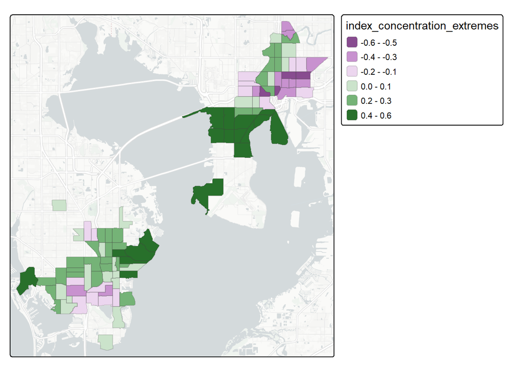

```r
tm_shape(tampa) +
  tm_polygons("index_concentration_extremes", col_alpha = 0.2) +
  tm_basemap("CartoDB.PositronNoLabels")
```

### 2.2.3 Cluster Analysis

**Global Structure**

```r
#calculate neighborhoods (queens)
nb_tampa <- poly2nb(tampa, queen = TRUE)

#set neighborhood weight matrix
nbw_tampa <- nb2listw(nb_tampa, style = "W", zero.policy = T)

#calculate Morans I
gmoran_tampa <- moran.mc(tampa$index_concentration_extremes, nbw_tampa, nsim = 99)
gmoran_tampa
```

```
##
##  Monte-Carlo simulation of Moran I
##
## data:  tampa$index_concentration_extremes
## weights: nbw_tampa
## number of simulations + 1: 100
##
## statistic = 0.66838, observed rank = 100, p-value = 0.01
## alternative hypothesis: greater
```

The result, a Moran’s I of 0.668, though less clustered than Detroit, is still quite highly clustered. This shows evidence of segregation within the city.

**Local Structure**

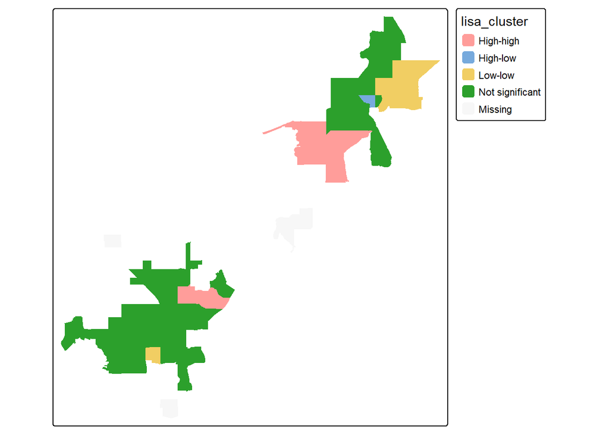

```r
locali_tampa <-localmoran_perm(tampa$index_concentration_extremes, nbw_tampa) %>%
  as_tibble() %>%
  set_names(c("local_i", "exp_i", "var_i", "z_i", "p_i",
              "p_i_sim", "pi_sim_folded", "skewness", "kurtosis"))

#bind LISA results
tampa_LISA <- tampa %>%
  bind_cols(locali_tampa)

#Divide into quadrants
tampa_LISA <- tampa_LISA %>%
  mutate(incz =  as.numeric(scale(index_concentration_extremes)),
         evratezlag = lag.listw(nbw_tampa, incz),
         lisa_cluster = case_when(
           p_i >= 0.05 ~ "Not significant",
           incz > 0 & local_i > 0 ~ "High-high",
           incz > 0 & local_i < 0 ~ "High-low",
           incz < 0 & local_i > 0 ~ "Low-low",
           incz < 0 & local_i < 0 ~ "Low-high"
         ))

#Map
tm_shape(tampa_LISA) + tm_polygons("lisa_cluster", col_alpha = 0)
```

As with Detroit, the LISA analysis supports the same segregation patterns observed on the map. High-high areas are concentrated essentially across the city center from low-low areas.

# 3 Hypotheses on Tampa

The OLS regressions built in this model will consist of historic redlining data, housing market data, and neighborhood environmental conditions to predict ICE values. This fits well within the context of the Tampa metropolitan area.

Redlining has been present in Tampa and St. Pete in particular since before the cities experienced their expansion. The University of Richmond’s Mapping Inequality Database provides an interactive map of historic HOLC grades for cities across the country. It reveals redlining policies as early as the 30’s, concentrated just north of the city center, where low ICE concentrations were found in the exploratory analysis (Nelson, 2023). These areas, predominantly Black, were marked for disinvestment early into the life of the city. St. Petersburg went as far as creating entire de-jure segregated districts, called “Colored Zones,” and refusing to approve permits for non-white residents operating outside of them (Schnur, 1996). These policies laid the groundwork for the segregation still observed today. For these reasons, redlining should be negatively correlated with ICE values, with the highest proportion redlined areas associated with low ICE.

Generational compounding, along with revitalization targeting privileged areas, leads contemporary housing markets as good predictors for ICE as well. If anything, this process could be even stronger than redlining. The Tampa metro has a history of gentrification, meaning areas that were historically underprivileged could have undergone developments, lifting them up on the map while displacing real communities. Hyde Park is a good example of this, used in Robert Kerstein’s “Stage Models of Gentrification” (Kerstein, 1990). In a city with such a recent history of urban expansion and development, initial redlining zones established in the 1930s likely still hold weight, but there has simply been more time and opportunity for factors to change. This would lead home value as a stronger, positively correlated predictor of ICE.

Another factor that can serve as a predictor for ICE values is neighborhood environmental conditions. This index is a composite of environmental health indicators such as air pollution, proximity to infrastructure, ozone exceedance days, etc. A nationwide study published by the Federal Reserve Bank of Richmond actually sought to find a connection between historically redlined zones and environmental risk exposure in 2023, and even included Tampa as a city for the study (Conzelmann et. al, 2023). With this said, the expectation of this report is that the environmental deprivation index will be strongly negatively associated with ICE, with higher values associated with lower ICE values.

# 4 Regression Analysis

## 4.1 Tampa

### 4.1.1 OLS Model

First, model variables are standardized to reflect variation within each individual city rather than nationwide impacts.

```r
# Standardize variables
standardized_tampa <- tampa |>
mutate(
redlining_z = scale(redlining),
home_value_z = scale(median_home_value),
env_dep_z = scale(env_deprivation_index)
)
```

```r
tampa_ols_model <- lm(index_concentration_extremes ~ redlining_z + home_value_z + env_dep_z, data = standardized_tampa)

#see results
summary(tampa_ols_model)
```

```
##
## Call:
## lm(formula = index_concentration_extremes ~ redlining_z + home_value_z +
##     env_dep_z, data = standardized_tampa)
##
## Residuals:
##      Min       1Q   Median       3Q      Max
## -0.53155 -0.10142  0.03834  0.13349  0.48067
##
## Coefficients:
##              Estimate Std. Error t value Pr(>|t|)
## (Intercept)   0.12930    0.01995   6.483 4.14e-09 ***
## redlining_z  -0.06111    0.02833  -2.157   0.0335 *
## home_value_z  0.15008    0.02806   5.348 6.23e-07 ***
## env_dep_z    -0.03756    0.02094  -1.794   0.0761 .
## ---
## Signif. codes:  0 '***' 0.001 '**' 0.01 '*' 0.05 '.' 0.1 ' ' 1
##
## Residual standard error: 0.1975 on 94 degrees of freedom
## Multiple R-squared:  0.5138, Adjusted R-squared:  0.4983
## F-statistic: 33.11 on 3 and 94 DF,  p-value: 1.075e-14
```

The results reveal significance among the redlining and home value as predictors. As predicted, home value (p = 6.23e-07) is a stronger predictor than historical redlining (p = 0.0335). Interestingly, environmental deprivation appears to be approaching significance at a p-value of 0.07, but not quite at the level of meeting the threshold. Directionally, all variables meet expectations, with redlining and environmental deprivation possessing negative correlation and home value possessing positive correlation.

With these results stated, it is important to note that spatial autocorrelation needs to be accounted for before major conclusions can be drawn. To do this, the OLS model residuals will be run through a Moran’s I test.

### 4.1.2 Spatial Autocorrelation Test

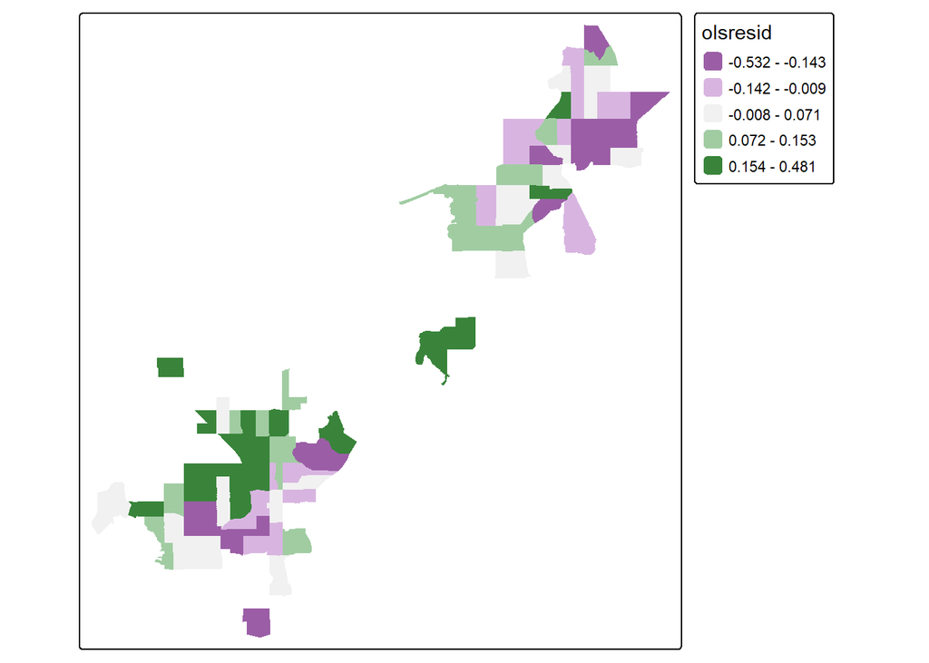

```r
#add residuals as a variable
standardized_tampa <-standardized_tampa |> mutate(olsresid = resid(tampa_ols_model))

#map residuals
tm_shape(standardized_tampa) + tm_polygons(fill = "olsresid",fill.scale = tm_scale_intervals(values = "Purple-Green", style = "quantile", n = 5), col_alpha = 0)
```

Visually, residuals appear to possess a spatial structure.

```r
#calculate Morans I
gmoran_tampa_resid <- moran.test(standardized_tampa$olsresid, nbw_tampa)
gmoran_tampa_resid
```

```
##
##  Moran I test under randomisation
##
## data:  standardized_tampa$olsresid
## weights: nbw_tampa
## n reduced by no-neighbour observations
##
## Moran I statistic standard deviate = 5.4415, p-value = 2.642e-08
## alternative hypothesis: greater
## sample estimates:
## Moran I statistic       Expectation          Variance
##       0.360391924      -0.010638298       0.004649236
```

The result confirms speculation from the residuals map. With a Moran’s I of 0.36, residuals appear to have moderate clustering. To account for this, a spatial model must be used.

### 4.1.3 Spatial Model

There are several types of spatial models. For the purpose of this report, a spatial error model will be used to account for autocorrelation. The primary thematic assumption of spatial error correction is that myriad unmeasured factors are influencing places, collectively causing convergence in variables, as opposed to spatial lag, which assumes observations directly impact one another.

When running both models across Tampa, the AIC values for are -63 for spatial error and -69 for spatial lag. This indicates a decent preference for lag. Detroit, on the other hand, has a spatial error AIC of -347 and spatial lag AIC of -322. This indicates a significant preference for the spatial error model. For the purpose of comparison, both models will be interpreted under spatial error, but the outputs of both models will be provided for each, and these AIC values will be discussed further in the city comparisons.

**Lag Model**

```r
#lag model
tampa_fit.lag<-lagsarlm(index_concentration_extremes ~ redlining_z + home_value_z + env_dep_z,
                  data = standardized_tampa,
                  listw = nbw_tampa, zero.policy = T)
#see results
summary(tampa_fit.lag)
```

```
##
## Call:lagsarlm(formula = index_concentration_extremes ~ redlining_z +
##     home_value_z + env_dep_z, data = standardized_tampa, listw = nbw_tampa,
##     zero.policy = T)
##
## Residuals:
##       Min        1Q    Median        3Q       Max
## -0.519892 -0.056069  0.024901  0.078110  0.460391
##
## Type: lag
## Regions with no neighbours included:
##  16 17 22
## Coefficients: (asymptotic standard errors)
##               Estimate Std. Error z value Pr(>|z|)
## (Intercept)   0.056415   0.019174  2.9423 0.003258
## redlining_z  -0.031150   0.022021 -1.4146 0.157194
## home_value_z  0.076459   0.023558  3.2455 0.001172
## env_dep_z    -0.014355   0.016134 -0.8897 0.373617
##
## Rho: 0.6102, LR test value: 37.863, p-value: 7.5909e-10
## Asymptotic standard error: 0.07976
##     z-value: 7.6505, p-value: 1.9984e-14
## Wald statistic: 58.53, p-value: 1.9984e-14
##
## Log likelihood: 40.89863 for lag model
## ML residual variance (sigma squared): 0.023082, (sigma: 0.15193)
## Number of observations: 98
## Number of parameters estimated: 6
## AIC: -69.797, (AIC for lm: -33.935)
## LM test for residual autocorrelation
## test value: 0.48526, p-value: 0.48605
```

**Error Model**

```r
#error model
tampa_fit.error <-errorsarlm(index_concentration_extremes ~ redlining_z + home_value_z + env_dep_z,
                      data = standardized_tampa,
                      listw = nbw_tampa, zero.policy = T)
#see results
summary(tampa_fit.error)
```

```
##
## Call:errorsarlm(formula = index_concentration_extremes ~ redlining_z +
##     home_value_z + env_dep_z, data = standardized_tampa, listw = nbw_tampa,
##     zero.policy = T)
##
## Residuals:
##       Min        1Q    Median        3Q       Max
## -0.544616 -0.071821  0.021714  0.083343  0.317913
##
## Type: error
## Regions with no neighbours included:
##  16 17 22
## Coefficients: (asymptotic standard errors)
##                Estimate Std. Error z value  Pr(>|z|)
## (Intercept)   0.1696726  0.0491912  3.4492 0.0005622
## redlining_z  -0.0235864  0.0290619 -0.8116 0.4170248
## home_value_z  0.0902535  0.0274825  3.2840 0.0010233
## env_dep_z    -0.0047899  0.0245006 -0.1955 0.8449996
##
## Lambda: 0.73342, LR test value: 31.869, p-value: 1.6489e-08
## Asymptotic standard error: 0.072494
##     z-value: 10.117, p-value: < 2.22e-16
## Wald statistic: 102.35, p-value: < 2.22e-16
##
## Log likelihood: 37.90209 for error model
## ML residual variance (sigma squared): 0.023171, (sigma: 0.15222)
## Number of observations: 98
## Number of parameters estimated: 6
## AIC: -63.804, (AIC for lm: -33.935)
```

With the addition of the spatial error term, all predictors lost much of their strength. Home values continues to be easily significant (p-value = 0.001). Redlining jumps from a p value of 0.0335 to 0.41, far beyond the metric for significance. Environmental deprivation, previously near the significance threshold, jumps to 0.845, beyond any reasonable lens for interpretation as a predictive variable.

Despite environmental deprivation losing significance as a causal predictor, an argument could still be made that there exists some overlapping spatial association between the variables in the OLS regression. With the extent that the variable lost strength from spatial autocorrelation, this could be explained by overarching, shared spatial processes that collectively impact both environmental deprivation and ICE values.

## 4.2 Detroit

This city’s regression analysis will follow the same steps as Tampa.

### 4.2.1 OLS Model

Variables are standardized.

```r
# Standardize variables
standardized_detroit <- detroit |>
mutate(
redlining_z = scale(redlining),
home_value_z = scale(median_home_value),
env_dep_z = scale(env_deprivation_index)
)
```

```r
detroit_ols_model <- lm(index_concentration_extremes ~ redlining_z + home_value_z + env_dep_z, data = standardized_detroit)

#see results
summary(detroit_ols_model)
```

```
##
## Call:
## lm(formula = index_concentration_extremes ~ redlining_z + home_value_z +
##     env_dep_z, data = standardized_detroit)
##
## Residuals:
##      Min       1Q   Median       3Q      Max
## -0.78689 -0.16166  0.00118  0.19657  0.49369
##
## Coefficients:
##              Estimate Std. Error t value Pr(>|t|)
## (Intercept)  -0.06250    0.01111  -5.628 3.26e-08 ***
## redlining_z  -0.01672    0.01189  -1.407   0.1602
## home_value_z  0.21976    0.01147  19.152  < 2e-16 ***
## env_dep_z    -0.02003    0.01163  -1.721   0.0859 .
## ---
## Signif. codes:  0 '***' 0.001 '**' 0.01 '*' 0.05 '.' 0.1 ' ' 1
##
## Residual standard error: 0.2337 on 439 degrees of freedom
## Multiple R-squared:  0.4896, Adjusted R-squared:  0.4861
## F-statistic: 140.4 on 3 and 439 DF,  p-value: < 2.2e-16
```

The results reveal significance only among home value (t value = 19.15). This value is essentially the strongest significance possible under the model. Historical redlining falls short of significance by a wide margin (p = 0.16). Environmental deprivation mirrors the OLS values of Tampa, approaching significance but not quite hitting the target at a p-value of 0.086. Directions of the coefficients again follow predictions.

Again, spatial autocorrelation testing is important before truly interpreting results.

### 4.2.2 Spatial Autocorrelation Test

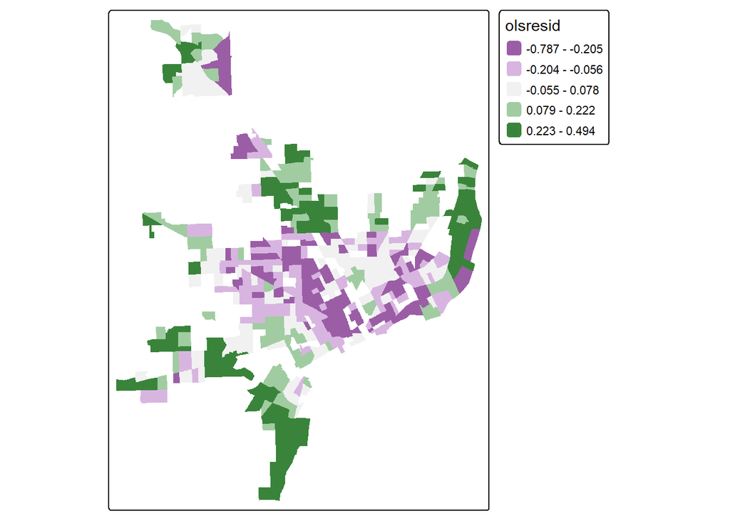

```r
#add residuals as a variable
standardized_detroit <-standardized_detroit |> mutate(olsresid = resid(detroit_ols_model))

#map residuals
tm_shape(standardized_detroit) + tm_polygons(fill = "olsresid",fill.scale = tm_scale_intervals(values = "Purple-Green", style = "quantile", n = 5), col_alpha = 0)
```

```r
#calculate Morans I
gmoran_detroit_resid <- moran.test(standardized_detroit$olsresid, nbw_detroit)
gmoran_detroit_resid
```

```
##
##  Moran I test under randomisation
##
## data:  standardized_detroit$olsresid
## weights: nbw_detroit
## n reduced by no-neighbour observations
##
## Moran I statistic standard deviate = 20.929, p-value < 2.2e-16
## alternative hypothesis: greater
## sample estimates:
## Moran I statistic       Expectation          Variance
##      0.6580374922     -0.0022675737      0.0009953722
```

As anticipated, residual clustering is high, with a Moran’s I of 0.658. Spatial modeling is required.

### 4.2.3 Spatial Model

**Lag Model**

```r
#lag model
detroit_fit.lag <-lagsarlm(index_concentration_extremes ~ redlining_z + home_value_z + env_dep_z,
                  data = standardized_detroit,
                  listw = nbw_detroit, zero.policy = T)
#see results
summary(detroit_fit.lag)
```

```
##
## Call:lagsarlm(formula = index_concentration_extremes ~ redlining_z +
##     home_value_z + env_dep_z, data = standardized_detroit, listw = nbw_detroit,
##     zero.policy = T)
##
## Residuals:
##       Min        1Q    Median        3Q       Max
## -0.565756 -0.086796  0.027503  0.102694  0.413014
##
## Type: lag
## Regions with no neighbours included:
##  431
## Coefficients: (asymptotic standard errors)
##                Estimate Std. Error z value Pr(>|z|)
## (Intercept)  -0.0181473  0.0076345 -2.3770  0.01745
## redlining_z  -0.0147839  0.0079073 -1.8697  0.06153
## home_value_z  0.1021070  0.0102869  9.9259  < 2e-16
## env_dep_z    -0.0038528  0.0077464 -0.4974  0.61893
##
## Rho: 0.67953, LR test value: 300.05, p-value: < 2.22e-16
## Asymptotic standard error: 0.031758
##     z-value: 21.397, p-value: < 2.22e-16
## Wald statistic: 457.84, p-value: < 2.22e-16
##
## Log likelihood: 167.3706 for lag model
## ML residual variance (sigma squared): 0.024137, (sigma: 0.15536)
## Number of observations: 443
## Number of parameters estimated: 6
## AIC: -322.74, (AIC for lm: -24.695)
## LM test for residual autocorrelation
## test value: 0.06327, p-value: 0.8014
```

**Error Model**

```r
#error model
detroit_fit.error <-errorsarlm(index_concentration_extremes ~ redlining_z + home_value_z + env_dep_z,
                      data = standardized_detroit,
                      listw = nbw_detroit, zero.policy = T)
#see results
summary(detroit_fit.error)
```

```
##
## Call:errorsarlm(formula = index_concentration_extremes ~ redlining_z +
##     home_value_z + env_dep_z, data = standardized_detroit, listw = nbw_detroit,
##     zero.policy = T)
##
## Residuals:
##       Min        1Q    Median        3Q       Max
## -0.563607 -0.082136  0.026279  0.092953  0.475794
##
## Type: error
## Regions with no neighbours included:
##  431
## Coefficients: (asymptotic standard errors)
##                Estimate Std. Error z value Pr(>|z|)
## (Intercept)  -0.0554550  0.0287165 -1.9311  0.05347
## redlining_z  -0.0199621  0.0113808 -1.7540  0.07943
## home_value_z  0.1764865  0.0132728 13.2969  < 2e-16
## env_dep_z    -0.0073903  0.0135728 -0.5445  0.58610
##
## Lambda: 0.75992, LR test value: 324.81, p-value: < 2.22e-16
## Asymptotic standard error: 0.031334
##     z-value: 24.252, p-value: < 2.22e-16
## Wald statistic: 588.16, p-value: < 2.22e-16
##
## Log likelihood: 179.7534 for error model
## ML residual variance (sigma squared): 0.021809, (sigma: 0.14768)
## Number of observations: 443
## Number of parameters estimated: 6
## AIC: -347.51, (AIC for lm: -24.695)
```

After considering spatial factors, Detroit reveals interesting results. As expected, home value remains very strongly associated with ICE (z value = 13.3). Redlining actually moved closer to significance after the correction, moving from a p value of 0.16 to 0.08. Environmental deprivation follows a similar trend as in Tampa, losing much of its strength to autocorrelation. This is an interesting contrast to the redlining: there is something unique between them that makes one gain significance in Detroit and the other lose it.

# 5 Discussion and Comparison

Predictors have behaved differently across both cities.

An important note of comparison is the initial model specifications. Tampa favored spatial lag while Detroit heavily favored spatial error. This could be seen as an example of spatial nonstationarity: the cities, born out of different contexts, experience spatial factors in entirely different ways. Perhaps Detroit, as an older, traditionally developed industrial city, had more opportunities for long-term spatial factors to make impacts on localized areas. Tampa, meanwhile, experiencing its most extensive growth only over the past century, may feel more impact from localized, contemporary processes. This is more similar to a multiple nuclei model, as opposed to Detroit’s more distinct zones or sectors.

Redlining revealed itself in different ways across both cities. In Tampa, redlining lost its interpretive significance by a wide margin after being controlled by spatial error, whereas in Detroit, redlining gained strength as a predictor after accounting for spatial autocorrelation, despite never meeting the threshold. This is another example of spatial nonstationarity. The variables not only carry different strength, but also respond completely differently to spatial corrections.

Despite the differences between both cities, both share connections in the data. Home value retained its significance as a predictor through everything. As a contemporary variable, it is not impacted by the historic changes within each city, and as a clear economic indicator, tying its output to privilege is clear and understandable. Environmental deprivation, on the other hand is less direct. Both cities had values near to significance thresholds on the OLS regression test, but lost it when accounting for spatial autocorrelation. The idea of lower privileged areas bearing a greater burden for environmental issues is a well-studied phenomenon, but a lot of this association is inherently spatially-rooted. Common factors may tie them to the similar areas without there being a direct causal link.

# 6 Conclusion

This paper has examined segregation patterns across Detroit and Tampa, both in terms of exploratory analysis, regression, and historical research. In doing so, the report has revealed how history and development patterns are fundamental in shaping not just the variables indicative of segregation, but how those variables apply differently across space. Detroit is a city at a low point, stuck in the midst of population decline and loss of industry. Its growth patterns are marked by historic expansions away from the city center over long periods of time. Tampa on the other hand is a rapidly-expanding growth center, with a bustling economic output and rising demand for investment. Growth behaves in a contemporary fashion, following localized processes. Both areas have histories of redlining, but that redlining presents completely differently. Meanwhile, some variables continue to present in similar ways. Environmental deprivation, for instance, consistently lost strength when corrected for spatial autocorrelation, and home value consistently maintained its significance.

The point is, understanding segregation within a city requires analytical compromise. There are universal factors, like home value, that impact variables across the board, but there are also a myriad of local processes, specific to an area, all working together to impact a city in unique ways. No two cities are the same. Understanding the full picture often requires unpacking history alongside data, and from that, successfully painting a picture of what segregation truly looks like within a community.

# 7 Bibliography

Carpenter, Craig Wesley. “Detroit - Redlining in Michigan.” Michigan State University. Accessed July 23, 2026. https://www.canr.msu.edu/redlining/detroit.

Conzelmann, Claire, Arianna Salazar-Miranda, Toan Phan, and Jeremy Hoffman. “Long-Term Causal Effects of Redlining on Environmental Risk Exposure.” Research Square, March 31, 2023. https://doi.org/10.21203/rs.3.rs-2705848/v1.

Farley, Reynolds. “The Bankruptcy of Detroit: What Role Did Race Play?” City and Community 14, no. 2 (June 2015): 118–37. https://doi.org/10.1111/cico.12106.

Gorrepati, Rishi. “Segregation and White Flight in Detroit.” ArcGIS Story Map, May 7, 2024. https://storymaps.arcgis.com/stories/12b84ab10e734e72b59beac8df64c903.

Kerstein, Robert. “From Annexation to Urban Renewal: Urban Development in Tampa during the 1950s and 1960s.” Tampa Bay History, 7, 19, no. 1 (June 1, 1991). https://doi.org/https://digitalcommons.usf.edu/tampabayhistory/vol19/iss1/7.

Kerstein, Robert. “Stage Models of Gentrification: An Examination.” Urban Affairs Quarterly 25, no. 4 (June 1990): 620–39. https://doi.org/10.1177/004208169002500406.

Nelson, Robert K., LaDale Winling, et al. “Mapping Inequality: Redlining in New Deal America.” Edited by Robert K. Nelson. American Panorama: An Atlas of United States History, 2023. https://dsl.richmond.edu/panorama/redlining.

Schnur, James Anthony. “An Overcast Forecast in the ’Sunshine City’”: Segregation and Inequality in St. Petersburg, Florida, before 1960.” FSU St. Petersburg Campus Faculty Publications 2982 (1996). https://doi.org/https://digitalcommons.usf.edu/fac_publications/2982 .

“Tampa Named One of the Fastest-Growing Economies in America.” City of Tampa, August 26, 2025. https://www.tampa.gov/news/2025-08/tampa-named-one-fastest-growing-economies-america-172416.